# IODS course project

Thordis Ingadottir

# Introduction to Open Data Science - Course Project

# About the project

*Write a short description about the course and add a link to your GitHub repository here. This is an R Markdown (.Rmd) file so you should use R Markdown syntax.*

This is a data science course at Helsinki University!  
The link to my github repository is: https://github.com/ThordisIngadottir/IODS-project/settings  
and here with a linked phrase:  
[My github repository](https://github.com/ThordisIngadottir/IODS-project/settings)

Here is a link to my published course diary: https://thordisingadottir.github.io/IODS-project/

```r
# This is a so-called "R chunk" where you can write R code.

date()
```

```
## [1] "Fri Nov 06 01:56:23 2020"
```

```r
numobj <- 5
2*numobj
```

```
## [1] 10
```

# Feelings:

I feel a little bit *overwhelmed* and confused in all this. I learned about this course on WebOodi. I am using Github and R for the **first time**, but I feel I am definitely making progress. Yay!

# The link:

The link to my github repository is: https://github.com/ThordisIngadottir/IODS-project/settings  
and here with a linked phrase:  
[My github repository](https://github.com/ThordisIngadottir/IODS-project/settings)

## What I want to learn from this course:

1. I want to be able to read and understand data better.
2. I want to be able to process data.

# Thordis Ingadottir’s “Project 2 in IODS, data wrangling and regression”

*Describe the work you have done this week and summarize your learning.*

- Describe your work and results clearly.
- Assume the reader has an introductory course level understanding of writing and reading R code as well as statistical methods.
- Assume the reader has no previous knowledge of your data or the more advanced methods you are using.

```r
date()
```

```
## [1] "Fri Nov 06 01:56:23 2020"
```

## This week:

I have been familiarising myself with R by doing the exercises in Datacamp. This included learning how to load data from the web, writing and reading locally, plotting, linear regression functions etc. This weeks project follows here:

## 1. Load the data locally

```r
learning2014 <- read.csv("./data/learning2014.csv", header = T, sep = ",")
learning2014
```

[output not shown]

[output cut: 152 more lines]

As can be seen this loaded a dataframe with student data. The headers list ‘variables’:

```r
head(learning2014)
```

```
##   X gender age attitude     deep  stra     surf points
## 1 1      F  53       37 3.583333 3.375 2.583333     25
## 2 2      M  55       31 2.916667 2.750 3.166667     12
## 3 3      F  49       25 3.500000 3.625 2.250000     24
## 4 4      M  53       35 3.500000 3.125 2.250000     10
## 5 5      M  49       37 3.666667 3.625 2.833333     22
## 6 6      F  38       38 4.750000 3.625 2.416667     21
```

with data about the students, their grades (points) and averaged answers to different categories of questions (the variables deep, stra, and surf). The dimensions of the dataframe are 7 such variables, times 166 “observations”, i.e. 166 students.

```r
str(learning2014)
```

```
## 'data.frame':    166 obs. of  8 variables:
##  $ X       : int  1 2 3 4 5 6 7 8 9 10 ...
##  $ gender  : chr  "F" "M" "F" "M" ...
##  $ age     : int  53 55 49 53 49 38 50 37 37 42 ...
##  $ attitude: int  37 31 25 35 37 38 35 29 38 21 ...
##  $ deep    : num  3.58 2.92 3.5 3.5 3.67 ...
##  $ stra    : num  3.38 2.75 3.62 3.12 3.62 ...
##  $ surf    : num  2.58 3.17 2.25 2.25 2.83 ...
##  $ points  : int  25 12 24 10 22 21 21 31 24 26 ...
```

```r
dim(learning2014)
```

```
## [1] 166   8
```

## 2. Graphical overview of the data:

Different ways of presenting quick overviews of the data include ‘pairs’ and ‘ggpairs’:

```r
library(GGally)
```

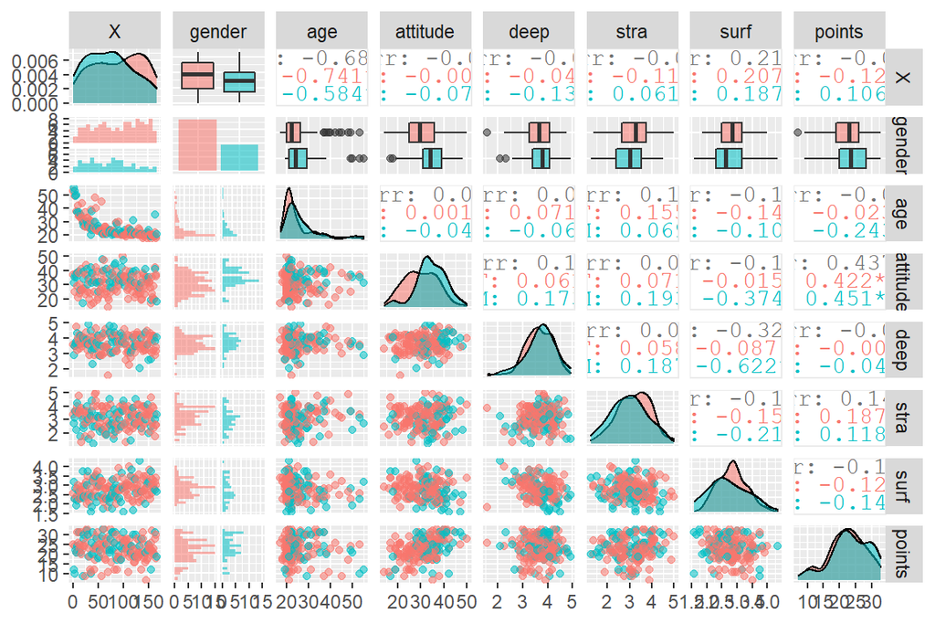

```r
library(ggplot2)
# pairs(learning2014[-1])
p <- ggpairs(learning2014, mapping = aes(col = gender, alpha = 0.3), lower = list(combo = wrap("facethist", bins = 20)))
p
```

The pairs function works on my console, but in the markup file it complains about non-numeric argument being supplied to ‘pairs’! Exactly the same function call. Apparently my console is more forgiving

There’s not an awful lot I can say about this data. In terms of correlation with points, the age is very clustered at the low end, attitude seems to have a decent correlation with points (surprise?). I can’t say there seems to be much of a correlation in the question variables deep, stra, and surf, except perhaps a little for stra. Maybe we’ll find out in the next section.

Summary of the variables (except for gender, that isn’t informative as the variable is of string type) follows:

```r
summary(learning2014$age)
```

```
##    Min. 1st Qu.  Median    Mean 3rd Qu.    Max.
##   17.00   21.00   22.00   25.51   27.00   55.00
```

```r
summary(learning2014$attitude)
```

```
##    Min. 1st Qu.  Median    Mean 3rd Qu.    Max.
##   14.00   26.00   32.00   31.43   37.00   50.00
```

```r
summary(learning2014$deep)
```

```
##    Min. 1st Qu.  Median    Mean 3rd Qu.    Max.
##   1.583   3.333   3.667   3.680   4.083   4.917
```

```r
summary(learning2014$stra)
```

```
##    Min. 1st Qu.  Median    Mean 3rd Qu.    Max.
##   1.250   2.625   3.188   3.121   3.625   5.000
```

```r
summary(learning2014$surf)
```

```
##    Min. 1st Qu.  Median    Mean 3rd Qu.    Max.
##   1.583   2.417   2.833   2.787   3.167   4.333
```

```r
summary(learning2014$points)
```

```
##    Min. 1st Qu.  Median    Mean 3rd Qu.    Max.
##    7.00   19.00   23.00   22.72   27.75   33.00
```

The output is self explanatory, min and max values, median and mean, and the 1st Qu. and 3rd Qu. give a very rough idea of the width of the distribution (how sharp the presumed peak at the mean).

## 3. Choose three explanatory variables and fit a regression model with points as the target variable.

I will choose attitude, stra and surf as explanatory variables (in the Datacamp these had the highest correlations with points), with points as the target variable. Create a regression model m:

```r
m <- lm(points ~ attitude + stra + surf, data = learning2014)
summary(m)
```

```
##
## Call:
## lm(formula = points ~ attitude + stra + surf, data = learning2014)
##
## Residuals:
##      Min       1Q   Median       3Q      Max
## -17.1550  -3.4346   0.5156   3.6401  10.8952
##
## Coefficients:
##             Estimate Std. Error t value Pr(>|t|)
## (Intercept) 11.01711    3.68375   2.991  0.00322 **
## attitude     0.33952    0.05741   5.913 1.93e-08 ***
## stra         0.85313    0.54159   1.575  0.11716
## surf        -0.58607    0.80138  -0.731  0.46563
## ---
## Signif. codes:  0 '***' 0.001 '**' 0.01 '*' 0.05 '.' 0.1 ' ' 1
##
## Residual standard error: 5.296 on 162 degrees of freedom
## Multiple R-squared:  0.2074, Adjusted R-squared:  0.1927
## F-statistic: 14.13 on 3 and 162 DF,  p-value: 3.156e-08
```

I will refrain from too much interpretation of these model parameters. The attitude does show a good fit, with probability of ‘null hypothesis’ in the last column being very low. Also a low std. error. The other two variable are less impressive fits with the points, although surf seems to be the worst without doubt.

## 4. Explain the relationship between the chosen explanatory variables and the target variable (interpret the model parameters).

This was addressed above. Attitude has the best fit. It is interesting that removing the surf variable improves the fit for stra, as shown below:

```r
m2 <- lm(points ~ attitude + stra, data = learning2014)
summary(m2)
```

```
##
## Call:
## lm(formula = points ~ attitude + stra, data = learning2014)
##
## Residuals:
##      Min       1Q   Median       3Q      Max
## -17.6436  -3.3113   0.5575   3.7928  10.9295
##
## Coefficients:
##             Estimate Std. Error t value Pr(>|t|)
## (Intercept)  8.97290    2.39591   3.745  0.00025 ***
## attitude     0.34658    0.05652   6.132 6.31e-09 ***
## stra         0.91365    0.53447   1.709  0.08927 .
## ---
## Signif. codes:  0 '***' 0.001 '**' 0.01 '*' 0.05 '.' 0.1 ' ' 1
##
## Residual standard error: 5.289 on 163 degrees of freedom
## Multiple R-squared:  0.2048, Adjusted R-squared:  0.1951
## F-statistic: 20.99 on 2 and 163 DF,  p-value: 7.734e-09
```

## 5. Diagnostic plots.

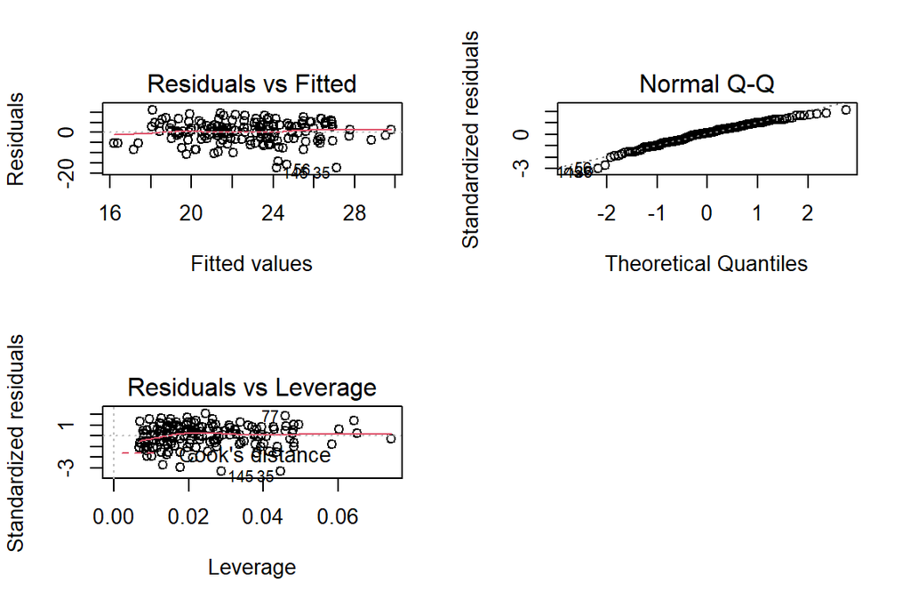

```r
par(mfrow = c(2,2))
plot(m, which = c(1,2,5))
```

The residuals look reasonably random. The QQ-plot does indicate problems at both ends and the leverage plot is a little sparse to the right hand side. The model assumptions are that errors are normally distributed and independent of explanatory variable.

This exercise has been very educational, as my prior statistics knowledge is not very extensive… and R seems very powerful!

(more chapters to be added similarly as we proceed with the course!)